# Laboratorio 2

## Minería de Datos

En este notebook se encuentra los resultados obtenidos.

A continuación se siguen las secciones pedidas en el enunciado (1.1 a 1.6).

## 1.1. Preprocesamiento del dataset

En esta sección se carga el archivo `movies_2026.csv`, se valida que estén presentes las columnas requeridas y se construye un dataset de trabajo (`df_model`) con variables limpias y transformadas para clustering.

- Se descartan identificadores y textos como `id` y `title` para el cálculo de distancias, porque no reflejan similitud semántica entre películas.
- Se mantienen variables **numéricas** como presupuesto, ingresos, popularidad, votos, cantidad de géneros, compañías, países y reparto, y el año de estreno.
- Se incluyen variables **categóricas simples**: `originalLanguage` (agrupada en los idiomas más frecuentes + categoría "OTHER") y `video` (normalizada a valores coherentes).
- Sobre algunas variables numéricas fuertemente sesgadas (`budget`, `revenue`, `popularity`, `voteCount`) se aplica una transformación logarítmica `log1p` para reducir el efecto de outliers.

Con estas decisiones, las variables que **no** aportan directamente a la formación de grupos (identificadores, textos libres u otros campos no incluidos en `NUMERIC_COLS` o `CATEGORICAL_COLS`) se usan solo como referencia o para interpretar los clusters, pero no para calcular las distancias.

```
Leyendo dataset desde: c:\Users\jmo\Documents\MineriaDeDatos\MineriaDatos-Lab2\Lab2\movies_2026.csv
Shape inicial: (19883, 28)
\nFaltantes (columnas requeridas):
```

|  | missing_count |
| --- | --- |
| video | 486 |
| castMenAmount | 162 |
| castWomenAmount | 37 |
| releaseYear | 2 |
| title | 1 |
| id | 0 |
| budget | 0 |
| revenue | 0 |
| runtime | 0 |
| genresAmount | 0 |
| voteCount | 0 |
| voteAvg | 0 |
| popularity | 0 |
| actorsAmount | 0 |
| productionCountriesAmount | 0 |
| productionCoAmount | 0 |
| originalLanguage | 0 |

```
\nDuplicados por id detectados: 0
```

```
Vista previa de features preparadas:
```

|  | id | title | budget | revenue | runtime | popularity | voteAvg | voteCount | genresAmount | productionCoAmount | productionCountriesAmount | actorsAmount | castWomenAmount | castMenAmount | releaseYear | originalLanguage | video |
| --- | --- | --- | --- | --- | --- | --- | --- | --- | --- | --- | --- | --- | --- | --- | --- | --- | --- |
| 0 | 1627085 | Immersed | 0.0 | 0.0 | 95 | 0.035078 | 0.0 | 0.0 | 2 | 0 | 0 | 8 | 2.0 | 5.0 | 2026.0 | OTHER | FALSE |
| 1 | 1626914 | Cinderella | 0.0 | 0.0 | 3 | 0.035078 | 0.0 | 0.0 | 1 | 0 | 0 | 4 | 0.0 | 0.0 | 2026.0 | EN | FALSE |
| 2 | 1626898 | Aladdin | 0.0 | 0.0 | 2 | 0.021174 | 0.0 | 0.0 | 1 | 0 | 0 | 3 | 0.0 | 0.0 | 2026.0 | EN | FALSE |
| 3 | 1626808 | THE RING AND THE DECK | 0.0 | 0.0 | 5 | 0.042005 | 0.0 | 0.0 | 3 | 0 | 0 | 7 | 0.0 | 0.0 | 2026.0 | ES | FALSE |
| 4 | 1626678 | Crimson High 3 | 0.0 | 0.0 | 12 | 0.037199 | 0.0 | 0.0 | 1 | 0 | 0 | 3 | 0.0 | 0.0 | 2026.0 | EN | FALSE |

```
\nResumen rápido de dtypes:
```

|  | dtype |
| --- | --- |
| budget | float64 |
| revenue | float64 |
| runtime | int64 |
| popularity | float64 |
| voteAvg | float64 |
| voteCount | float64 |
| genresAmount | int64 |
| productionCoAmount | int64 |
| productionCountriesAmount | int64 |
| actorsAmount | int64 |
| castWomenAmount | float64 |
| castMenAmount | float64 |
| releaseYear | float64 |
| originalLanguage | string |
| video | string |

## 1.2. Tendencia al agrupamiento (Hopkins y VAT)

Una vez construido el conjunto de variables numéricas y categóricas preprocesadas (`X_model`), evaluamos si los datos muestran **tendencia natural a formar clusters**.

En el código siguiente se calcula Hopkins sobre una muestra de las observaciones y se genera una imagen VAT sobre otra muestra, para hacer el análisis viable incluso con muchos registros.

```
Forma de X preprocesada (densa para métricas/modelos): (19883, 27)
```

```
Estadístico de Hopkins (muestra de 5000 observaciones): 0.013
Interpretación aproximada: patrón cercano a aleatorio o muy regular (poca tendencia clara a clústeres).
```

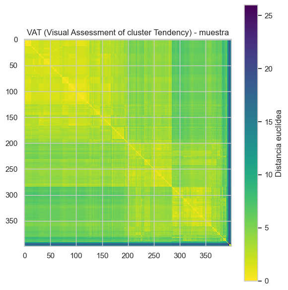

```
Resultados del grid (top 15 por silhouette):
```

|  | algorithm | k | status | silhouette_score | calinski_harabasz_score | davies_bouldin_score | inertia | runtime_sec | n_clusters_efectivos | cluster_max_share | error |
| --- | --- | --- | --- | --- | --- | --- | --- | --- | --- | --- | --- |
| 0 | KMeans | 2 | ok | 0.796884 | 1442.788680 | 0.412095 | 253367.416212 | 1.652613 | 2 | 0.998391 | None |
| 20 | Birch | 4 | ok | 0.594220 | 1872.476778 | 0.812123 | NaN | 0.943275 | 4 | 0.975054 | None |
| 19 | Birch | 3 | ok | 0.592076 | 1794.640614 | 0.919571 | NaN | 0.952836 | 3 | 0.976714 | None |
| 18 | Birch | 2 | ok | 0.584203 | 1803.996542 | 1.062822 | NaN | 1.030796 | 2 | 0.982095 | None |
| 9 | MiniBatchKMeans | 2 | ok | 0.386521 | 9834.609142 | 1.102256 | 181854.637721 | 0.054016 | 2 | 0.502439 | None |
| 1 | KMeans | 3 | ok | 0.381126 | 7250.508567 | 1.474017 | 157135.623029 | 0.012826 | 3 | 0.474224 | None |
| 10 | MiniBatchKMeans | 3 | ok | 0.379290 | 7241.916330 | 1.461095 | 157501.036885 | 0.054518 | 3 | 0.477292 | None |
| 26 | Birch | 10 | ok | 0.374220 | 4812.439949 | 0.863439 | NaN | 0.945368 | 10 | 0.494744 | None |
| 25 | Birch | 9 | ok | 0.373035 | 5216.310246 | 0.941156 | NaN | 0.955713 | 9 | 0.494744 | None |
| 24 | Birch | 8 | ok | 0.372031 | 5602.281166 | 1.059010 | NaN | 0.988717 | 8 | 0.494744 | None |
| 21 | Birch | 5 | ok | 0.371136 | 4504.067226 | 0.834391 | NaN | 0.958155 | 5 | 0.732284 | None |
| 23 | Birch | 7 | ok | 0.362812 | 5874.503521 | 1.064099 | NaN | 1.007705 | 7 | 0.494744 | None |
| 22 | Birch | 6 | ok | 0.359748 | 6519.731372 | 1.000122 | NaN | 0.973551 | 6 | 0.494744 | None |
| 11 | MiniBatchKMeans | 4 | ok | 0.333910 | 5131.664287 | 2.199798 | 153303.194805 | 0.108830 | 4 | 0.473269 | None |
| 12 | MiniBatchKMeans | 5 | ok | 0.329911 | 4261.841861 | 2.084009 | 147052.439282 | 0.118528 | 5 | 0.470502 | None |

```
\nResumen por estado:
```

| status | count |
| --- | --- |
| ok | 27 |

```
Mejor configuración seleccionada:
```

```
algorithm                    MiniBatchKMeans
k                                          2
status                                    ok
silhouette_score                    0.386521
calinski_harabasz_score          9834.609142
davies_bouldin_score                1.102256
inertia                        181854.637721
runtime_sec                         0.054016
n_clusters_efectivos                       2
cluster_max_share                   0.502439
error                                   None
degenerate_filter_applied               True
dtype: object
```

```
Vista previa de salida etiquetada:
```

|  | id | title | cluster_label | best_algorithm | best_k |
| --- | --- | --- | --- | --- | --- |
| 0 | 1627085 | Immersed | 0 | MiniBatchKMeans | 2 |
| 1 | 1626914 | Cinderella | 0 | MiniBatchKMeans | 2 |
| 2 | 1626898 | Aladdin | 0 | MiniBatchKMeans | 2 |
| 3 | 1626808 | THE RING AND THE DECK | 0 | MiniBatchKMeans | 2 |
| 4 | 1626678 | Crimson High 3 | 0 | MiniBatchKMeans | 2 |

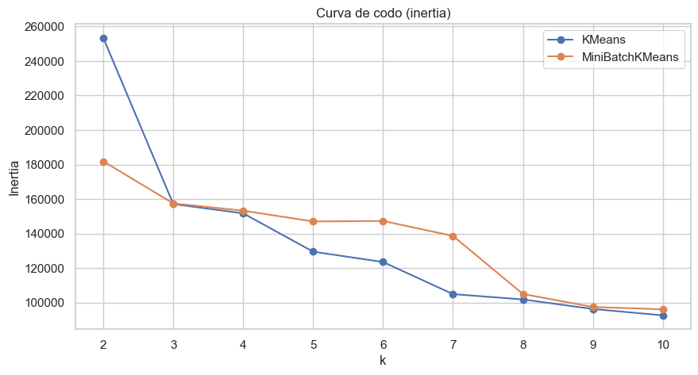

## 1.3. Elección del número de clusters (curva de codo)

En esta sección se explora el número adecuado de grupos `k`:

- Se evalúan distintos valores de `k` para varios algoritmos (KMeans, MiniBatchKMeans, Birch) y se registran métricas internas (inercia, silueta, Calinski-Harabasz, Davies-Bouldin).
- La **curva de codo** usa la inercia de KMeans y MiniBatchKMeans para identificar a partir de qué punto incrementar `k` deja de reducir significativamente la inercia.
- En conjunto con las métricas de calidad (especialmente el **índice de silueta**), se selecciona un `k` razonable para seguir trabajando (almacenado en la variable `best_k`).

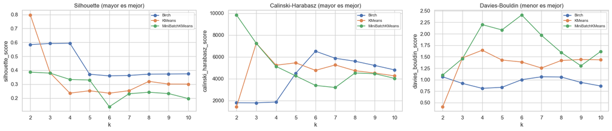

```
Tamaños de cluster (KMeans):
```

| cluster_kmeans | count |
| --- | --- |
| 0 | 19851 |
| 1 | 32 |

```
\nTamaños de cluster (Jerárquico - Ward):
```

| cluster_hier | count |
| --- | --- |
| 0 | 10072 |
| 1 | 9811 |

```
\nTabla de contingencia entre particiones (KMeans vs Jerárquico):
```

| cluster_hier cluster_kmeans | 0 | 1 |
| --- | --- | --- |
| 0 | 10040 | 9811 |
| 1 | 32 | 0 |

## 1.4. Agrupamiento con k-medias y clustering jerárquico

En esta sección se comparan explícitamente dos algoritmos clásicos de clustering usando el mismo número de grupos `k` seleccionado previamente (`best_k`):

- **K-medias** (KMeans), que busca centroides esféricos en el espacio de características.
- **Clustering jerárquico aglomerativo** (linkage tipo Ward), que construye una jerarquía de fusiones de grupos y permite obtener particiones a diferentes niveles.

Se entrenan ambos modelos sobre `X_model`, se obtienen las etiquetas de cluster y se comparan los tamaños de los grupos y la tabla de contingencia entre las particiones.

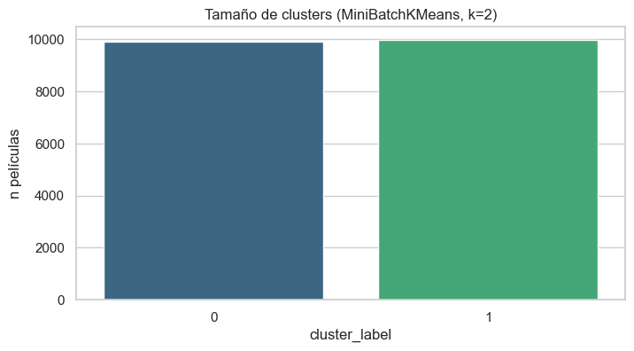

```
Tamaños de cluster:
```

| cluster_label | count | share |
| --- | --- | --- |
| 0 | 9893 | 0.497561 |
| 1 | 9990 | 0.502439 |

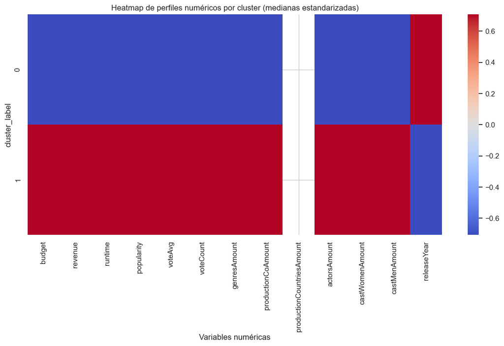

```
Perfiles numéricos (medianas):
```

| cluster_label | budget | revenue | runtime | popularity | voteAvg | voteCount | genresAmount | productionCoAmount | productionCountriesAmount | actorsAmount | castWomenAmount | castMenAmount | releaseYear |
| --- | --- | --- | --- | --- | --- | --- | --- | --- | --- | --- | --- | --- | --- |
| 0 | 0.000000 | 0.000000 | 10.0 | 0.052877 | 0.0000 | 0.000000 | 1.0 | 0.0 | 1.0 | 3.0 | 0.0 | 0.0 | 2025.0 |
| 1 | 13.574648 | 12.383242 | 100.0 | 3.125905 | 6.5025 | 6.035481 | 3.0 | 3.0 | 1.0 | 21.0 | 6.0 | 11.0 | 2013.0 |

```
\nDistribución relativa por cluster - originalLanguage
```

| originalLanguage cluster_label | DE | EN | ES | FR | IT | JA | KO | NL | OTHER | PT | ZH |
| --- | --- | --- | --- | --- | --- | --- | --- | --- | --- | --- | --- |
| 0 | 0.038108 | 0.423734 | 0.086223 | 0.083190 | 0.020216 | 0.023552 | 0.017285 | 0.017588 | 0.205903 | 0.059638 | 0.024563 |
| 1 | 0.008408 | 0.777678 | 0.038539 | 0.027127 | 0.010210 | 0.063564 | 0.016517 | 0.001802 | 0.040140 | 0.003804 | 0.012212 |

```
\nDistribución relativa por cluster - video
```

| video cluster_label | FALSE | TRUE | UNKNOWN |
| --- | --- | --- | --- |
| 0 | 0.998686 | 0.001011 | 0.000303 |
| 1 | 0.944244 | 0.007407 | 0.048348 |

## 1.5. Calidad del agrupamiento (índice de silueta)

Para evaluar la calidad de los clusters generados por cada algoritmo se utiliza el **índice de silueta**, que toma valores entre -1 y 1:

- valores cercanos a 1 indican que las observaciones están bien cohesionadas dentro de su grupo y bien separadas de los demás;
- valores cercanos a 0 indican solapamiento entre clusters;
- valores negativos indican que muchas observaciones estarían mejor asignadas a otros grupos.

Se calcula la silueta media para KMeans, para el clustering jerárquico y se reporta también la del modelo "ganador" (`best_algorithm`, `best_k`) empleado en el resto del análisis.

```
Silueta media (KMeans, k=2): 0.797
Silueta media (Jerárquico-Ward, k=2): 0.382
Silueta media (modelo seleccionado: MiniBatchKMeans, k=2): 0.387
```

## 1.6. Interpretación de los grupos

En las celdas siguientes se calculan perfiles de cada clúster:

- Para las variables **numéricas** se resumen medianas por grupo y se muestran en un mapa de calor estandarizado, lo que permite detectar, por ejemplo, clusters de alto presupuesto/ingresos versus producciones más modestas.
- Para las variables **categóricas** (`originalLanguage`, `video`) se construyen tablas de frecuencias relativas por cluster.

A partir de estos perfiles se pueden identificar hallazgos como:

- grupos de películas con **alto presupuesto y alta recaudación**, posiblemente "blockbusters";
- grupos con **mucha presencia de actores/actrices** y alta popularidad, que podrían asociarse a elencos corales o producciones muy promocionadas;
- grupos dominados por ciertos **idiomas** o países de producción.

Estos patrones pueden ser útiles para segmentar el catálogo (por ejemplo, para recomendaciones, análisis de riesgo de inversión o diseño de campañas de marketing específicas por tipo de película).

# 2. Reglas de Asociación

## 2.1 Generación de reglas con el algoritmo A priori

En esta sección se aplicará el algoritmo **A priori** para identificar patrones de co-ocurrencia entre características de las películas.

Dado que el algoritmo requiere variables categóricas, se realizará previamente:

- Eliminación de variables irrelevantes o identificadores únicos.
- Discretización de variables numéricas.
- Construcción de transacciones.
- Generación de reglas con distintos niveles de soporte y confianza.
- Evaluación de las reglas mediante lift.

El objetivo es identificar asociaciones interesantes que puedan generar *insights* estratégicos para CineVision Studios.

```
Cantidad de transacciones construidas: 4502
Dimensión antes de eliminar ítems frecuentes: (4502, 1359)
Ítems eliminados por alta frecuencia: 1
Dimensión después de limpieza: (4502, 1358)
Cantidad de reglas generadas: 13
```

|  | antecedents | consequents | antecedent support | consequent support | support | confidence | lift | representativity | leverage | conviction | zhangs_metric | jaccard | certainty | kulczynski |
| --- | --- | --- | --- | --- | --- | --- | --- | --- | --- | --- | --- | --- | --- | --- |
| 2 | frozenset({budget_high, pop_high}) | frozenset({revenue_high}) | 0.176144 | 0.333407 | 0.150600 | 0.854981 | 2.564374 | 1.0 | 0.091872 | 4.596591 | 0.740471 | 0.419554 | 0.782447 | 0.653340 |
| 10 | frozenset({budget_high, rating_medium, pop_high}) | frozenset({revenue_high}) | 0.115060 | 0.333407 | 0.098179 | 0.853282 | 2.559277 | 1.0 | 0.059817 | 4.543355 | 0.688481 | 0.280279 | 0.779898 | 0.573876 |
| 7 | frozenset({rating_high, revenue_low}) | frozenset({budget_low}) | 0.041315 | 0.340293 | 0.035762 | 0.865591 | 2.543663 | 1.0 | 0.021703 | 4.908219 | 0.633019 | 0.103404 | 0.796260 | 0.485341 |
| 4 | frozenset({rating_low, revenue_high}) | frozenset({budget_high}) | 0.058641 | 0.332741 | 0.047757 | 0.814394 | 2.447531 | 1.0 | 0.028244 | 3.595028 | 0.628267 | 0.138979 | 0.721838 | 0.478959 |
| 6 | frozenset({budget_low, pop_low}) | frozenset({revenue_low}) | 0.170147 | 0.333407 | 0.133496 | 0.784595 | 2.353263 | 1.0 | 0.076768 | 3.094606 | 0.692964 | 0.360744 | 0.676857 | 0.592498 |
| 11 | frozenset({rating_medium, revenue_high, pop_hi... | frozenset({budget_high}) | 0.129054 | 0.332741 | 0.098179 | 0.760757 | 2.286335 | 1.0 | 0.055237 | 2.789047 | 0.645986 | 0.270006 | 0.641455 | 0.527909 |
| 3 | frozenset({pop_high, revenue_high}) | frozenset({budget_high}) | 0.198801 | 0.332741 | 0.150600 | 0.757542 | 2.276671 | 1.0 | 0.084451 | 2.752059 | 0.699903 | 0.395335 | 0.636636 | 0.605073 |
| 8 | frozenset({budget_low, rating_low}) | frozenset({revenue_low}) | 0.070635 | 0.333407 | 0.053310 | 0.754717 | 2.263648 | 1.0 | 0.029759 | 2.717647 | 0.600663 | 0.151995 | 0.632035 | 0.457305 |
| 9 | frozenset({rating_high, revenue_high}) | frozenset({pop_high}) | 0.050866 | 0.333407 | 0.037095 | 0.729258 | 2.187287 | 1.0 | 0.020135 | 2.462092 | 0.571903 | 0.106846 | 0.593841 | 0.420258 |
| 5 | frozenset({budget_high, rating_medium}) | frozenset({revenue_high}) | 0.215238 | 0.333407 | 0.156597 | 0.727554 | 2.182178 | 1.0 | 0.084835 | 2.446698 | 0.690326 | 0.399433 | 0.591286 | 0.598621 |
| 12 | frozenset({rating_medium, budget_low, pop_low}) | frozenset({revenue_low}) | 0.091737 | 0.333407 | 0.064860 | 0.707022 | 2.120594 | 1.0 | 0.034274 | 2.275229 | 0.581807 | 0.180025 | 0.560484 | 0.450779 |
| 0 | frozenset({budget_high}) | frozenset({revenue_high}) | 0.332741 | 0.333407 | 0.233674 | 0.702270 | 2.106341 | 1.0 | 0.122736 | 2.238914 | 0.787165 | 0.540318 | 0.553355 | 0.701568 |
| 1 | frozenset({revenue_high}) | frozenset({budget_high}) | 0.333407 | 0.332741 | 0.233674 | 0.700866 | 2.106341 | 1.0 | 0.122736 | 2.230636 | 0.787952 | 0.540318 | 0.551697 | 0.701568 |

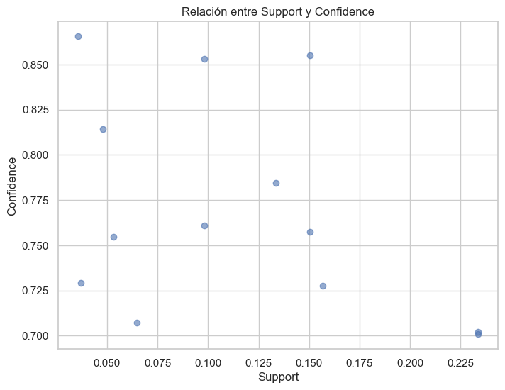

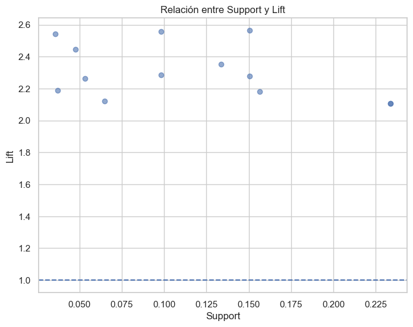

## Discusión de Resultados

### Eliminación de variables extremadamente frecuentes

- Alto soporte,
- Alta confianza,
- Pero bajo valor analítico (reglas triviales).

Por ejemplo, si una categoría aparece en casi todas las películas, el algoritmo tenderá a generar reglas donde dicha categoría aparece en el antecedente o consecuente sin aportar un insight real.

### Interpretación estratégica

No obstante, es importante señalar que las reglas de asociación identifican correlaciones y no relaciones causales. Por lo tanto, los hallazgos deben utilizarse como apoyo para decisiones estratégicas y no como determinantes absolutos.

## 3. Análisis de Componentes Principales (PCA)

En esta sección se estudia la estructura de correlación entre las **variables numéricas** del dataset y se evalúa si es conveniente aplicar Análisis de Componentes Principales (ACP) / análisis factorial como técnica de reducción de dimensión.

Luego se obtienen los componentes principales, se decide cuántos retener según la varianza explicada y se interpretan sus coeficientes. Al final se mantiene también el "espacio de trabajo" de PCA original sobre `X_model` para visualizaciones adicionales.

## 3.1. Transformación de variables categóricas y matriz de correlación

En este análisis de componentes principales se trabaja **principalmente con las variables numéricas** del conjunto de datos (`NUMERIC_COLS`).

- Las variables categóricas (`originalLanguage`, `video`) ya fueron transformadas mediante *one-hot encoding* para el modelo de clustering (`X_model`). Aunque sería posible incluir estas dummies en el PCA, esto suele producir componentes dominados por categorías muy frecuentes y dificulta la interpretación.
- Por ello, para el ACP "clásico" se prefiere utilizar solo las variables numéricas (posiblemente transformadas y estandarizadas), y dejar las categóricas para interpretar los componentes o analizar su relación con los scores de PCA.

```
Matriz de correlación (primeras columnas):
```

|  | budget | revenue | runtime | popularity | voteAvg | voteCount | genresAmount | productionCoAmount | productionCountriesAmount | actorsAmount | castWomenAmount | castMenAmount | releaseYear |
| --- | --- | --- | --- | --- | --- | --- | --- | --- | --- | --- | --- | --- | --- |
| budget | 1.000000 | 0.787435 | 0.462355 | 0.520800 | 0.424576 | 0.685627 | 0.363464 | 0.397984 | 0.065644 | -0.022906 | -0.040744 | -0.064678 | -0.494380 |
| revenue | 0.787435 | 1.000000 | 0.514106 | 0.579897 | 0.482748 | 0.749274 | 0.370024 | 0.424441 | 0.065559 | -0.020392 | -0.040439 | -0.065714 | -0.532093 |
| runtime | 0.462355 | 0.514106 | 1.000000 | 0.672490 | 0.596262 | 0.703159 | 0.408350 | 0.458283 | 0.186419 | -0.007961 | -0.015815 | 0.039575 | -0.492886 |
| popularity | 0.520800 | 0.579897 | 0.672490 | 1.000000 | 0.758851 | 0.885196 | 0.518562 | 0.514253 | 0.215247 | 0.034839 | 0.074461 | 0.115892 | -0.543847 |
| voteAvg | 0.424576 | 0.482748 | 0.596262 | 0.758851 | 1.000000 | 0.784410 | 0.474937 | 0.445499 | 0.185602 | 0.027938 | 0.041715 | 0.082164 | -0.538068 |

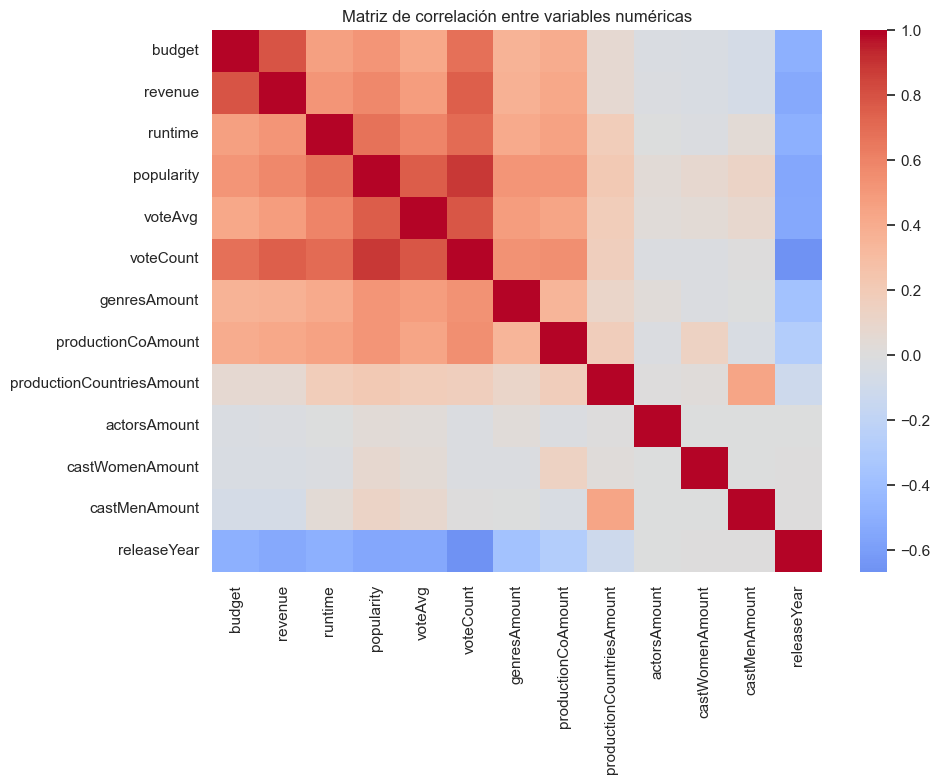

## 3.2. Viabilidad del ACP: índice KMO y prueba de esfericidad de Bartlett

Para estudiar si es **conveniente** aplicar Análisis de Componentes Principales / análisis factorial se usan dos pruebas clásicas:

- **Índice KMO (Kaiser-Meyer-Olkin)**: mide la adecuación muestral. Valores cercanos a 1 indican que las correlaciones parciales son pequeñas y que el modelo factorial es apropiado. Como regla práctica:
  - < 0.5: inaceptable; 0.5–0.6: mediocre; 0.6–0.7: aceptable; 0.7–0.8: buena; > 0.8: muy buena.
- **Prueba de esfericidad de Bartlett**: contrasta si la matriz de correlaciones es la identidad. Un *p-valor* pequeño (p < 0.05) permite rechazar la hipótesis nula y concluye que hay correlaciones suficientes para aplicar ACP.

En la siguiente celda se calculan ambos indicadores sobre las variables numéricas imputadas, y se interpreta si el ACP es recomendable.

```
Prueba de esfericidad de Bartlett: chi2 = 140805.95, p-valor = 0
Índice KMO global: 0.869
- KMO >= 0.8: muy buena adecuación para ACP.
```

## 3.3. Análisis de Componentes Principales con variables numéricas

En esta sección se realiza el ACP usando solo las variables numéricas (ya transformadas y estandarizadas):

```
Componentes (numéricos) para >=80% varianza explicada: 6
Componentes (numéricos) para >=90% varianza explicada: 9
Componentes (numéricos) para >=95% varianza explicada: 10
```

|  | component | explained_variance_ratio | cumulative_explained_variance |
| --- | --- | --- | --- |
| 0 | 1 | 0.417431 | 0.417431 |
| 1 | 2 | 0.113854 | 0.531285 |
| 2 | 3 | 0.082763 | 0.614048 |
| 3 | 4 | 0.078074 | 0.692123 |
| 4 | 5 | 0.061409 | 0.753531 |
| 5 | 6 | 0.055349 | 0.808881 |
| 6 | 7 | 0.047303 | 0.856183 |
| 7 | 8 | 0.042117 | 0.898300 |
| 8 | 9 | 0.032569 | 0.930869 |
| 9 | 10 | 0.030871 | 0.961740 |
| 10 | 11 | 0.017779 | 0.979519 |
| 11 | 12 | 0.015754 | 0.995273 |
| 12 | 13 | 0.004727 | 1.000000 |

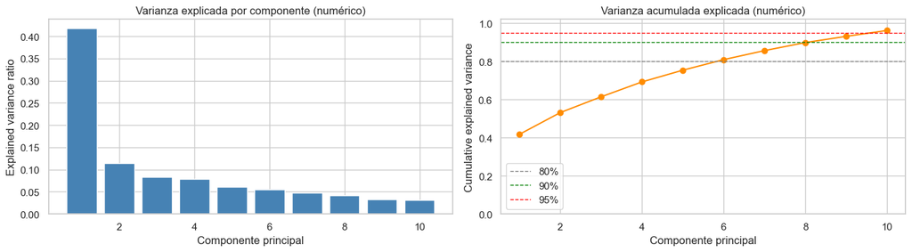

```
Loadings (primeros componentes):
```

|  | PC1 | PC2 | PC3 | PC4 | PC5 |
| --- | --- | --- | --- | --- | --- |
| budget | 0.316855 | -0.203501 | -0.153313 | -0.105409 | -0.496958 |
| revenue | 0.337197 | -0.196415 | -0.139623 | -0.091980 | -0.438691 |
| runtime | 0.331839 | 0.048136 | -0.007170 | 0.004014 | 0.153092 |
| popularity | 0.378172 | 0.100219 | 0.082738 | 0.064932 | 0.146328 |
| voteAvg | 0.346275 | 0.094354 | 0.068718 | 0.088639 | 0.276416 |
| voteCount | 0.410554 | -0.034206 | -0.030818 | -0.011000 | 0.017797 |
| genresAmount | 0.264528 | -0.009672 | 0.005507 | 0.118590 | 0.518976 |
| productionCoAmount | 0.267946 | 0.021522 | 0.328255 | -0.080294 | 0.029272 |
| productionCountriesAmount | 0.098760 | 0.646855 | -0.065190 | -0.059735 | -0.174852 |
| actorsAmount | 0.000190 | 0.020489 | 0.030056 | 0.968672 | -0.220865 |
| castWomenAmount | 0.008581 | 0.081862 | 0.888660 | -0.058070 | -0.246244 |
| castMenAmount | 0.016218 | 0.683267 | -0.174903 | -0.038709 | -0.144443 |
| releaseYear | -0.304054 | 0.067984 | 0.105780 | -0.030705 | 0.089240 |

```
Componentes para >=80% varianza explicada: 7
Componentes para >=90% varianza explicada: 10
Componentes para >=95% varianza explicada: 12
```

|  | component | explained_variance_ratio | cumulative_explained_variance |
| --- | --- | --- | --- |
| 0 | 1 | 0.400493 | 0.400493 |
| 1 | 2 | 0.108480 | 0.508972 |
| 2 | 3 | 0.078753 | 0.587725 |
| 3 | 4 | 0.074301 | 0.662026 |
| 4 | 5 | 0.058671 | 0.720698 |
| 5 | 6 | 0.052753 | 0.773450 |
| 6 | 7 | 0.045044 | 0.818494 |
| 7 | 8 | 0.040155 | 0.858649 |
| 8 | 9 | 0.031224 | 0.889872 |
| 9 | 10 | 0.029733 | 0.919605 |
| 10 | 11 | 0.018245 | 0.937850 |
| 11 | 12 | 0.016480 | 0.954330 |
| 12 | 13 | 0.014453 | 0.968783 |
| 13 | 14 | 0.006650 | 0.975433 |
| 14 | 15 | 0.004677 | 0.980111 |

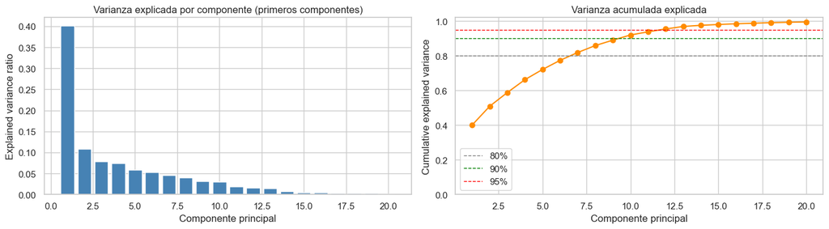

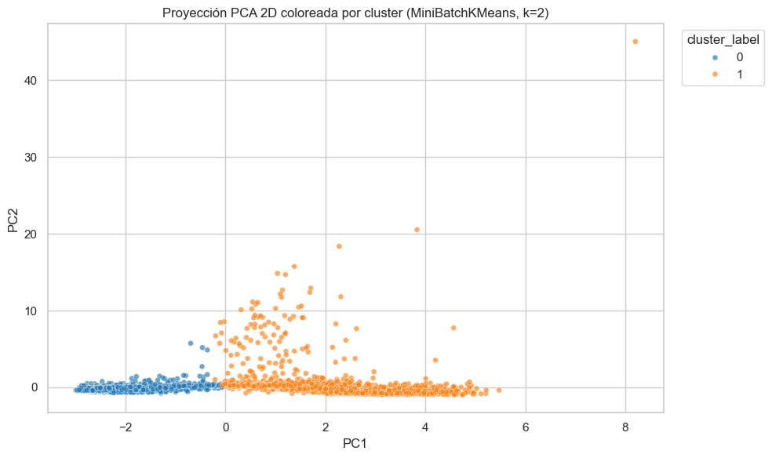

```
Varianza explicada por PC1 y PC2 (modelo de visualización 2D):
```

```
PC1    0.400493
PC2    0.108480
Name: explained_variance_ratio, dtype: float64
```

```
Archivo exportado: C:\Users\jmo\Documents\MineriaDeDatos\MineriaDatos-Lab2\Lab2\movies_2026_clusters_initial.csv
Filas exportadas: 19,883
```

# 4. Otros Algoritmos de Aprendizaje No Supervisado

## 4.1 Aplicación de UMAP (Uniform Manifold Approximation and Projection)

Con el propósito de explorar estructuras latentes adicionales en el conjunto de datos y complementar los resultados obtenidos mediante clustering y Análisis de Componentes Principales (PCA), se decidió aplicar el algoritmo **UMAP (Uniform Manifold Approximation and Projection)**.

UMAP es una técnica de reducción de dimensionalidad basada en fundamentos de geometría diferencial y teoría de grafos. Su principal ventaja radica en su capacidad para preservar tanto la estructura local como parte de la estructura global de los datos al proyectarlos en un espacio de menor dimensión. A diferencia de PCA, que se basa únicamente en relaciones lineales y maximización de varianza explicada, UMAP permite capturar relaciones no lineales presentes en el conjunto de datos.

El dataset analizado contiene múltiples variables numéricas transformadas (por ejemplo, presupuesto, ingresos, popularidad y conteo de votos) así como variables categóricas codificadas. Esta combinación genera un espacio de alta dimensionalidad en el que pueden existir patrones complejos no lineales que no son completamente capturados por métodos lineales tradicionales. En este contexto, UMAP resulta adecuado para:

- Detectar posibles agrupaciones naturales no evidentes.
- Visualizar la estructura intrínseca del mercado cinematográfico.
- Identificar regiones densas o transiciones graduales entre segmentos de películas.
- Evaluar la coherencia estructural de los clústeres previamente obtenidos.

La aplicación de UMAP en dos dimensiones permite una representación visual que facilita la interpretación de patrones y relaciones entre películas, ofreciendo una perspectiva complementaria a los métodos previamente utilizados. Posteriormente, se analizará si la proyección obtenida revela estructuras relevantes que aporten información estratégica adicional para CineVision Studios.

```
Dimensión del dataset transformado: (19883, 27)
¿Contiene NaN?: False
Dimensión reducida: (19883, 2)
```

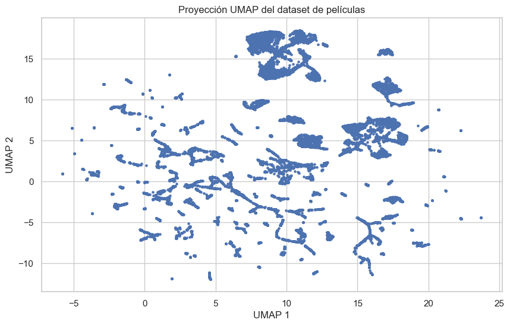

## 4.2 Interpretación de los Resultados y Relevancia de los Hallazgos

La proyección obtenida mediante UMAP revela una estructura claramente no uniforme del dataset. En la representación bidimensional se observan múltiples agrupaciones compactas distribuidas en distintas regiones del espacio, así como zonas con menor densidad de observaciones.

En la parte superior del gráfico se identifica una región con alta concentración de puntos, lo que sugiere la existencia de un subconjunto de películas que comparten características similares en términos de variables financieras, popularidad y estructura de producción. Esta agrupación compacta indica homogeneidad relativa dentro de ese segmento del mercado.

En contraste, la zona central y la región inferior presentan una distribución más fragmentada, con pequeños conglomerados dispersos. Esta fragmentación sugiere mayor heterogeneidad estructural entre películas, lo cual podría reflejar diversidad en presupuestos, niveles de popularidad o combinaciones de características productivas.

También se observan puntos aislados en los extremos del espacio proyectado, lo cual podría representar películas con perfiles atípicos o extremos en alguna de las variables consideradas (por ejemplo, producciones con presupuestos muy altos o desempeños comerciales inusuales).

La forma no lineal de las agrupaciones confirma la pertinencia del uso de UMAP, ya que este método permite capturar relaciones complejas que no necesariamente serían evidentes en una reducción lineal como PCA. La existencia de múltiples “islas” o subconjuntos sugiere que el mercado cinematográfico no se organiza únicamente en pocos segmentos amplios, sino en múltiples nichos con características diferenciadas.

Desde una perspectiva estratégica, estos resultados permiten inferir que:

- Existen segmentos relativamente homogéneos que podrían representar modelos de producción consolidados.
- También hay regiones más dispersas que podrían corresponder a mercados intermedios o híbridos.
- Los puntos aislados podrían representar oportunidades de nicho o casos atípicos que merecen análisis individual.

Es importante destacar que UMAP es una técnica de reducción de dimensionalidad orientada a visualización y exploración estructural. Por lo tanto, los patrones identificados deben interpretarse como evidencia exploratoria que complementa los resultados obtenidos mediante clustering y no como una segmentación definitiva.

En conclusión, la aplicación de UMAP permitió evidenciar una estructura interna compleja y no lineal del dataset, aportando una visión adicional sobre la organización del mercado cinematográfico y reforzando la utilidad de aplicar métodos no supervisados complementarios para comprender su dinámica.